# News-Driven Markets: Unified Pipeline (Week-by-Week)

This notebook presents a clean, end-to-end pipeline for stock price prediction using financial news sentiment and historical data, with each week's logic and code clearly separated for clarity and reproducibility.

# Project Overview: Week-by-Week Summary

This notebook documents a week-by-week pipeline for stock return prediction using both price/history and news sentiment features for multiple companies. Below is a summary of the key steps and objectives for each week:

## Week 1: Data Collection & Cleaning

- Collected historical stock price data and financial news headlines for TSLA, AAPL, MSFT, NVDA, and GOOG.
- Cleaned and preprocessed the raw data, saving as *_News_Cleaned.csv and* _Stock_Cleaned.csv for each company.

## Week 2: Sentiment Analysis & Data Merge

- Applied VADER sentiment analysis to news headlines to quantify daily sentiment.
- Aggregated daily sentiment scores and merged them with stock price data on the date column.
- Saved as *_Daily_Sentiment.csv and* _Merged1.csv for each company.

## Week 3: Feature Engineering

- Created rolling averages, lagged features, and daily returns to enhance predictive power.
- Engineered both price-based and sentiment-based features.
- Saved as *_Features1.csv for each company.

## Week 4: Exploratory Data Analysis (EDA)

- Visualized price, sentiment, moving averages, correlations, and return distributions.
- Explored relationships between sentiment and price movements.

## Week 5: Linear Models (Price-only vs Price+Sentiment)

- Trained and evaluated linear models (Linear Regression, Ridge, Lasso) using only price/history features and then with price+sentiment features.
- Compared model performance to assess the value of sentiment features.

## Week 6: Advanced ML Models (Price-only)

- Trained advanced machine learning models (Random Forest, XGBoost, LightGBM, CatBoost, SVR, KNN) using only price/history features.
- Evaluated regression and classification performance.

## Week 7: Advanced ML Models (Price+Sentiment)

- Trained the same advanced models as Week 6, now including sentiment features.
- Compared results to Week 6 to assess the predictive value of sentiment.
- Visualized feature importances for tree-based models.

## Week 8: Model Comparison & Hyperparameter Tuning

- Recorded and compared results for all non-tuned and hyperparameter-tuned models across all companies and feature sets.
- Created a summary table showing the best non-tuned and tuned model performance (R²) for each company and feature set.
- Reflected on the impact and value of hyperparameter tuning for this problem.

## Week 1: Data Collection & Cleaning

- Downloaded news and stock data for TSLA, AAPL, MSFT, NVDA, GOOG.
- Cleaned and saved as *_News_Cleaned.csv and* _Stock_Cleaned.csv for each company.

```python
# Week 1: Data Loading (already cleaned and saved in CSVs)
import pandas as pd
companies = ['TSLA', 'AAPL', 'MSFT', 'NVDA', 'GOOG']
news_data = {}
stock_data = {}
for symbol in companies:
    news_data[symbol] = pd.read_csv(f'{symbol}_News_Cleaned.csv')
    stock_data[symbol] = pd.read_csv(f'{symbol}_Stock_Cleaned.csv')
```

## Week 2: Sentiment Analysis & Merge

- Applied VADER sentiment to news headlines.
- Aggregated daily sentiment and merged with stock data on date.
- Saved as *_Daily_Sentiment.csv and* _Merged1.csv.

```python
# Week 2: Sentiment Analysis & Merge
from vaderSentiment.vaderSentiment import SentimentIntensityAnalyzer
analyzer = SentimentIntensityAnalyzer()
merged_data = {}
for symbol in companies:
    news = news_data[symbol]
    news['compound'] = news['headline'].apply(lambda x: analyzer.polarity_scores(str(x))['compound'])
    daily_sentiment = news.groupby('datetime')['compound'].sum().reset_index()
    daily_sentiment.columns = ['Date', 'Sentiment']
    stock = stock_data[symbol]
    stock['Date'] = pd.to_datetime(stock['Date'])
    daily_sentiment['Date'] = pd.to_datetime(daily_sentiment['Date'])
    merged = pd.merge(stock, daily_sentiment, on='Date', how='left')
    merged['Sentiment'] = merged['Sentiment'].fillna(0)
    merged_data[symbol] = merged
```

## Week 3: Feature Engineering

- Created rolling averages, lagged features, and daily returns.
- Saved as *_Features1.csv for each company.

```python
# Week 3: Feature Engineering
features_data = {}
for symbol, df in merged_data.items():
    df = df.copy()
    df['Close'] = pd.to_numeric(df['Close'], errors='coerce')
    df['Sentiment'] = pd.to_numeric(df['Sentiment'], errors='coerce')
    df['Price_MA7'] = df['Close'].rolling(window=7).mean()
    df['Sentiment_MA7'] = df['Sentiment'].rolling(window=7).mean()
    df['Sentiment_Lag1'] = df['Sentiment'].shift(1)
    df['Return'] = df['Close'].pct_change()
    df['Close_lag1'] = df['Close'].shift(1)
    df['Price_MA7_lag1'] = df['Price_MA7'].shift(1)
    df = df.dropna().reset_index(drop=True)
    features_data[symbol] = df
```

### Addressing Class Imbalance for Classification

```python
# Install imbalanced-learn if not already installed
import sys
!{sys.executable} -m pip install -q imbalanced-learn

from imblearn.over_sampling import RandomOverSampler

# Week 3.5: Address Class Imbalance in Sentiment/Return Direction (for Classification)
balanced_data = {}
for company, df in features_data.items():
    # Create return_direction column if not present
    if 'return_direction' not in df.columns:
        df = df.copy()
        df['return_direction'] = (df['Return'] > 0).astype(int)
    # Only use numeric features for classification (no Date, no Timestamp)
    classification_features = ['Sentiment_Lag1', 'Sentiment_MA7', 'Price_MA7', 'Price_MA7_lag1', 'Close_lag1']
    X = df[classification_features]
    y = df['return_direction']
    ros = RandomOverSampler(random_state=42)
    X_res, y_res = ros.fit_resample(X, y)
    balanced_data[company] = (X_res, y_res)

print("Balanced datasets created for classification tasks (return direction) for all companies.")
```

[output not shown]

## Week 4: Exploratory Data Analysis (EDA)

- Visualized price, sentiment, moving averages, correlations, and distributions.

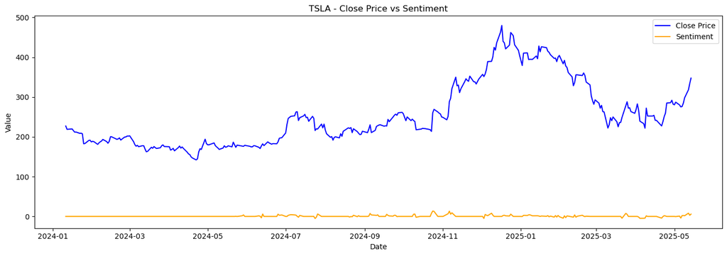

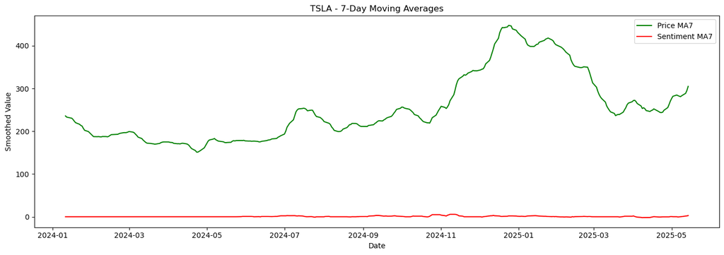

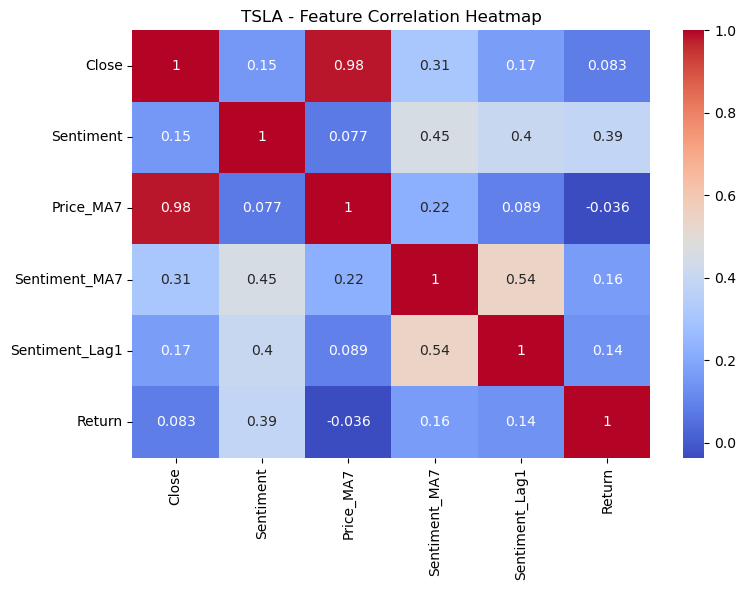

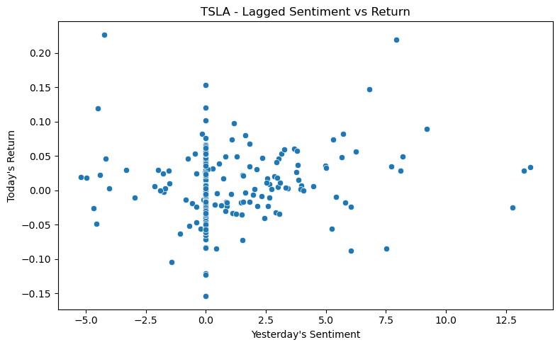

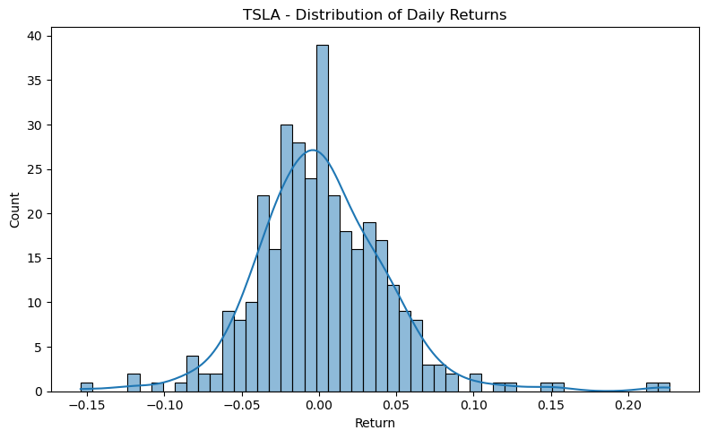

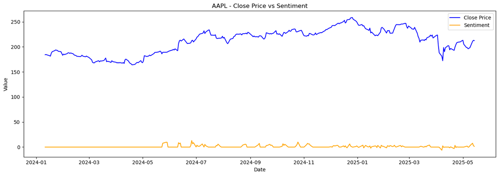

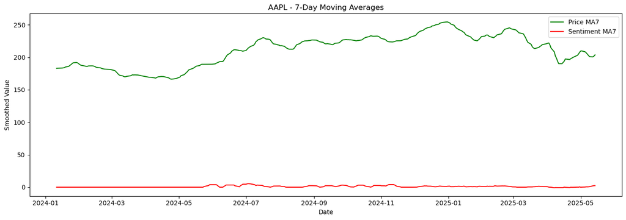

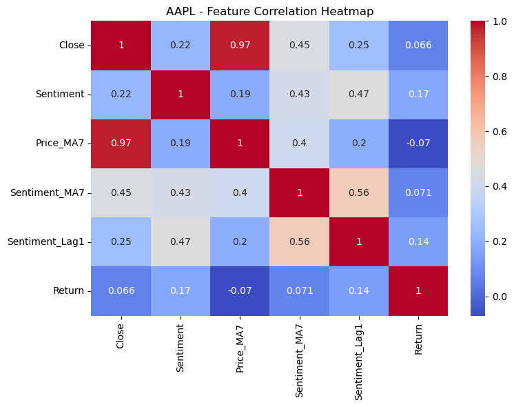

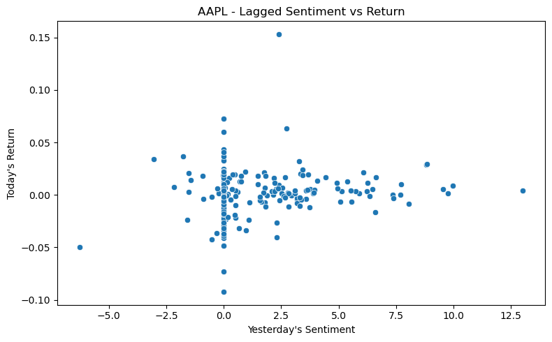

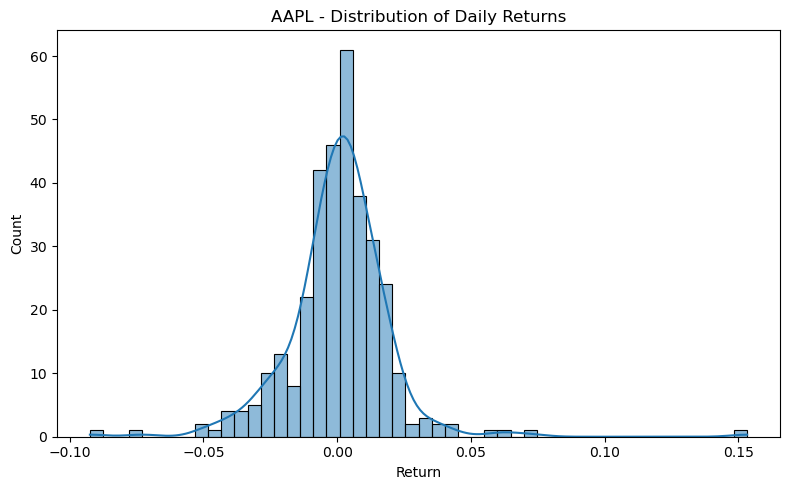

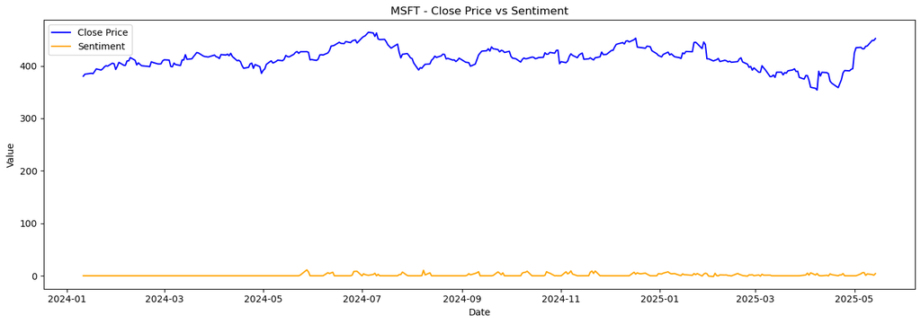

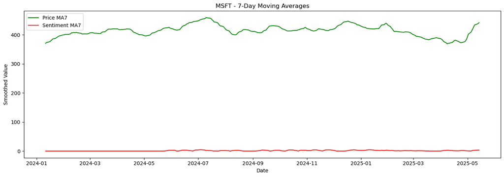

[13 more figures not shown]

```python
# Week 4: EDA (for all companies)
import matplotlib.pyplot as plt
import seaborn as sns
for symbol in features_data.keys():
    df = features_data[symbol]
    plt.figure(figsize=(14, 5))
    plt.plot(df['Date'], df['Close'], label='Close Price', color='blue')
    plt.plot(df['Date'], df['Sentiment'], label='Sentiment', color='orange')
    plt.title(f'{symbol} - Close Price vs Sentiment')
    plt.xlabel('Date')
    plt.ylabel('Value')
    plt.legend()
    plt.tight_layout()
    plt.show()
    plt.figure(figsize=(14, 5))
    plt.plot(df['Date'], df['Price_MA7'], label='Price MA7', color='green')
    plt.plot(df['Date'], df['Sentiment_MA7'], label='Sentiment MA7', color='red')
    plt.title(f'{symbol} - 7-Day Moving Averages')
    plt.xlabel('Date')
    plt.ylabel('Smoothed Value')
    plt.legend()
    plt.tight_layout()
    plt.show()
    plt.figure(figsize=(8, 6))
    corr = df[['Close', 'Sentiment', 'Price_MA7', 'Sentiment_MA7', 'Sentiment_Lag1', 'Return']].corr()
    sns.heatmap(corr, annot=True, cmap='coolwarm')
    plt.title(f'{symbol} - Feature Correlation Heatmap')
    plt.tight_layout()
    plt.show()
    plt.figure(figsize=(8, 5))
    sns.scatterplot(x='Sentiment_Lag1', y='Return', data=df)
    plt.title(f'{symbol} - Lagged Sentiment vs Return')
    plt.xlabel("Yesterday's Sentiment")
    plt.ylabel("Today's Return")
    plt.tight_layout()
    plt.show()
    plt.figure(figsize=(8, 5))
    sns.histplot(df['Return'].dropna(), bins=50, kde=True)
    plt.title(f'{symbol} - Distribution of Daily Returns')
    plt.xlabel('Return')
    plt.tight_layout()
    plt.show()
```

## Week 5: Linear Models (Price-only vs Price+Sentiment)

- Compare linear model performance using only price/history features vs. price+sentiment features for all companies.

```python
# Week 5: Linear Models for Return Prediction (Price-only vs Price+Sentiment)
from sklearn.model_selection import train_test_split
from sklearn.linear_model import LinearRegression, Ridge, Lasso
from sklearn.metrics import mean_squared_error, r2_score
for symbol, df in features_data.items():
    print(f'\n=== {symbol} (Price-only) ===')
    X_price = df[['Price_MA7', 'Price_MA7_lag1', 'Close_lag1']]
    y = df['Return']
    X_train, X_test, y_train, y_test = train_test_split(X_price, y, test_size=0.2, shuffle=False)
    for name, model in {'Linear': LinearRegression(), 'Ridge': Ridge(), 'Lasso': Lasso()}.items():
        model.fit(X_train, y_train)
        preds = model.predict(X_test)
        r2 = r2_score(y_test, preds)
        mse = mean_squared_error(y_test, preds)
        print(f'{name} (Price-only): R2={r2:.4f}, MSE={mse:.6f}')
    print(f'\n=== {symbol} (Price+Sentiment) ===')
    X_sent = df[['Sentiment_Lag1', 'Sentiment_MA7', 'Price_MA7', 'Price_MA7_lag1', 'Close_lag1']]
    X_train, X_test, y_train, y_test = train_test_split(X_sent, y, test_size=0.2, shuffle=False)
    for name, model in {'Linear': LinearRegression(), 'Ridge': Ridge(), 'Lasso': Lasso()}.items():
        model.fit(X_train, y_train)
        preds = model.predict(X_test)
        r2 = r2_score(y_test, preds)
        mse = mean_squared_error(y_test, preds)
        print(f'{name} (Price+Sentiment): R2={r2:.4f}, MSE={mse:.6f}')

# Week 6: Classification Modeling (using balanced data)
from sklearn.metrics import classification_report, accuracy_score

classification_results = {}

for company in companies:
    print(f"\n--- {company} ---")
    X_res, y_res = balanced_data[company]
    # Example: Logistic Regression (replace/add other models as needed)
    from sklearn.linear_model import LogisticRegression
    clf = LogisticRegression(max_iter=1000, random_state=42)
    clf.fit(X_res, y_res)
    y_pred = clf.predict(X_res)
    acc = accuracy_score(y_res, y_pred)
    print(f"Accuracy (balanced): {acc:.3f}")
    print(classification_report(y_res, y_pred))
    classification_results[company] = acc

# Repeat similar logic for other classifiers (Random Forest, XGBoost, etc.) using X_res, y_res
```

[output not shown]

## Week 6: ML Models (Price-only)

- Use tree-based and advanced ML models (Random Forest, XGBoost, LightGBM, CatBoost, SVM, KNN) with only price/history features.

```python
# Week 6: Advanced ML Models (Price-only)
from sklearn.ensemble import RandomForestRegressor, RandomForestClassifier
from sklearn.svm import SVR
from sklearn.neighbors import KNeighborsRegressor
from sklearn.metrics import mean_squared_error, mean_absolute_error, r2_score, accuracy_score, classification_report
import lightgbm as lgb
import catboost as cb
import xgboost as xgb
for symbol, df in features_data.items():
    print(f'\n=== {symbol} Advanced ML (Price-only) ===')
    X = df[['Price_MA7', 'Price_MA7_lag1', 'Close_lag1']]
    y = df['Return']
    X_train, X_test, y_train, y_test = train_test_split(X, y, test_size=0.2, shuffle=False)
    models = {
        'RandomForest': RandomForestRegressor(random_state=42),
        'XGBoost': xgb.XGBRegressor(random_state=42, verbosity=0),
        'LightGBM': lgb.LGBMRegressor(random_state=42),
        'CatBoost': cb.CatBoostRegressor(verbose=0, random_state=42),
        'SVR': SVR(),
        'KNN': KNeighborsRegressor()
    }
    for name, model in models.items():
        model.fit(X_train, y_train)
        preds = model.predict(X_test)
        r2 = r2_score(y_test, preds)
        mse = mean_squared_error(y_test, preds)
        mae = mean_absolute_error(y_test, preds)
        print(f'{name} (Price-only): R2={r2:.4f}, MSE={mse:.6f}, MAE={mae:.6f}')
    # Classification: Predict direction (up/down)
    y_class = (df['Return'] > 0).astype(int)
    X_train, X_test, y_train, y_test = train_test_split(X, y_class, test_size=0.2, shuffle=False)
    clf = RandomForestClassifier(n_estimators=100, random_state=42)
    clf.fit(X_train, y_train)
    y_pred = clf.predict(X_test)
    acc = accuracy_score(y_test, y_pred)
    print(f'RandomForestClassifier (Price-only) Accuracy: {acc:.4f}')
    print(classification_report(y_test, y_pred))
```

[output not shown]

[output cut: 1169 more lines]

```
   macro avg       0.62      0.60      0.56        68
weighted avg       0.63      0.57      0.55        68

CatBoost (Price-only): R2=0.0424, MSE=0.000588, MAE=0.018227
SVR (Price-only): R2=-0.3625, MSE=0.000836, MAE=0.021953
KNN (Price-only): R2=0.0475, MSE=0.000585, MAE=0.018497
RandomForestClassifier (Price-only) Accuracy: 0.5735
              precision    recall  f1-score   support

           0       0.72      0.35      0.47        37
           1       0.52      0.84      0.64        31

    accuracy                           0.57        68
   macro avg       0.62      0.60      0.56        68
weighted avg       0.63      0.57      0.55        68
```

## Week 7: ML Models (Price+Sentiment)

- Use the same ML models as Week 6, but now include sentiment features. Compare results to Week 6 to show the predictive value of sentiment.

```python
# Week 7: Advanced ML Models (Price+Sentiment)
for symbol, df in features_data.items():
    print(f'\n=== {symbol} Advanced ML (Price+Sentiment) ===')
    X = df[['Sentiment_Lag1', 'Sentiment_MA7', 'Price_MA7', 'Price_MA7_lag1', 'Close_lag1']]
    y = df['Return']
    X_train, X_test, y_train, y_test = train_test_split(X, y, test_size=0.2, shuffle=False)
    models = {
        'RandomForest': RandomForestRegressor(random_state=42),
        'XGBoost': xgb.XGBRegressor(random_state=42, verbosity=0),
        'LightGBM': lgb.LGBMRegressor(random_state=42),
        'CatBoost': cb.CatBoostRegressor(verbose=0, random_state=42),
        'SVR': SVR(),
        'KNN': KNeighborsRegressor()
    }
    for name, model in models.items():
        model.fit(X_train, y_train)
        preds = model.predict(X_test)
        r2 = r2_score(y_test, preds)
        mse = mean_squared_error(y_test, preds)
        mae = mean_absolute_error(y_test, preds)
        print(f'{name} (Price+Sentiment): R2={r2:.4f}, MSE={mse:.6f}, MAE={mae:.6f}')
    # Classification: Predict direction (up/down)
    y_class = (df['Return'] > 0).astype(int)
    X_train, X_test, y_train, y_test = train_test_split(X, y_class, test_size=0.2, shuffle=False)
    clf = RandomForestClassifier(n_estimators=100, random_state=42)
    clf.fit(X_train, y_train)
    y_pred = clf.predict(X_test)
    acc = accuracy_score(y_test, y_pred)
    print(f'RandomForestClassifier (Price+Sentiment) Accuracy: {acc:.4f}')
    print(classification_report(y_test, y_pred))
```

[output not shown]

[output cut: 1171 more lines]

```
   macro avg       0.61      0.58      0.54        68
weighted avg       0.62      0.56      0.53        68

CatBoost (Price+Sentiment): R2=0.0550, MSE=0.000580, MAE=0.018404
SVR (Price+Sentiment): R2=-0.3625, MSE=0.000836, MAE=0.021953
KNN (Price+Sentiment): R2=-0.0337, MSE=0.000634, MAE=0.019545
RandomForestClassifier (Price+Sentiment) Accuracy: 0.5588
              precision    recall  f1-score   support

           0       0.71      0.32      0.44        37
           1       0.51      0.84      0.63        31

    accuracy                           0.56        68
   macro avg       0.61      0.58      0.54        68
weighted avg       0.62      0.56      0.53        68
```

## Feature Importance Visualization (Tree-Based Models)

Visualize which features are most important for each company and model (Random Forest, XGBoost, LightGBM, CatBoost) using the trained regressors from Week 7.

```
=== TSLA Feature Importances ===
```

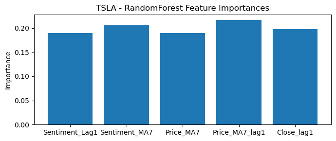

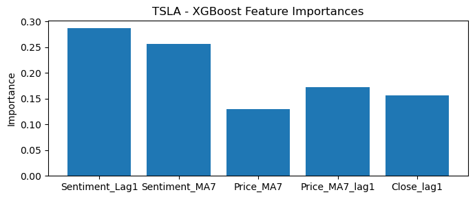

[output not shown]

[output cut: 50 more lines]

[output not shown]

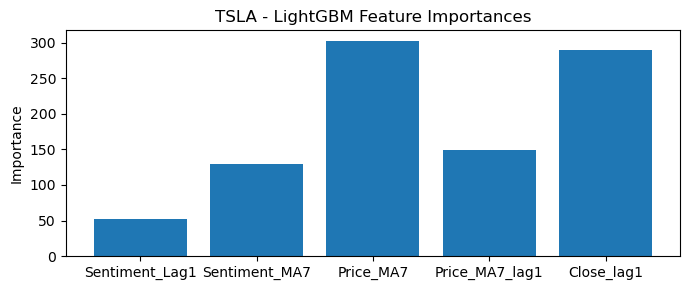

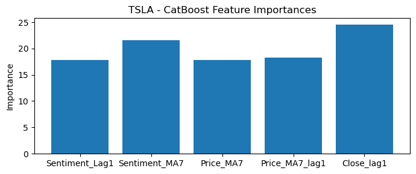

```
=== AAPL Feature Importances ===
```

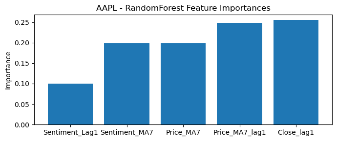

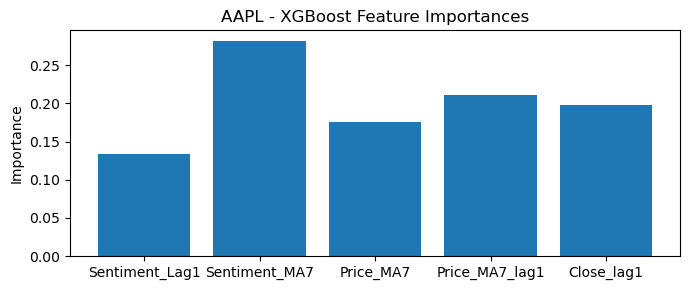

[output not shown]

[output cut: 50 more lines]

[output not shown]

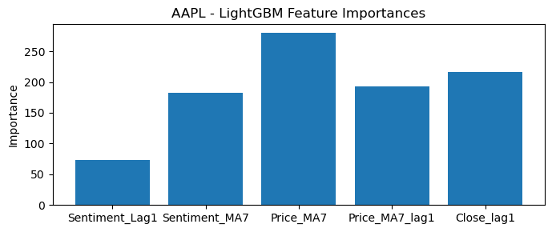

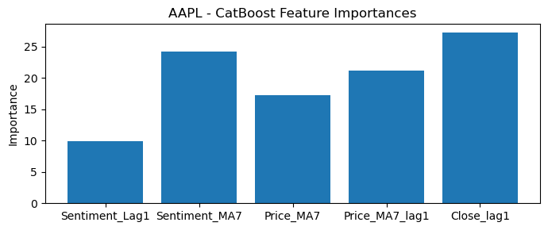

```
=== MSFT Feature Importances ===
```

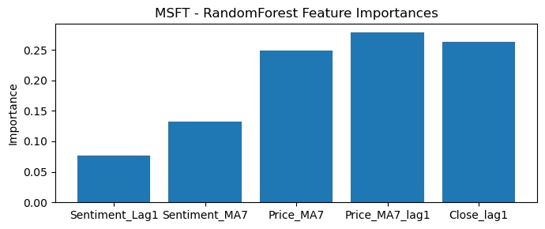

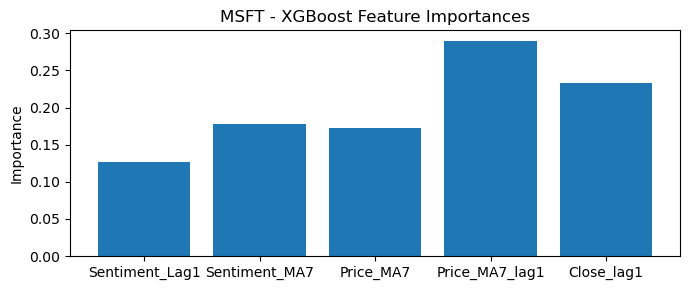

[output not shown]

[output cut: 50 more lines]

[output not shown]

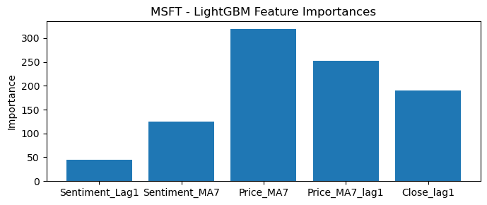

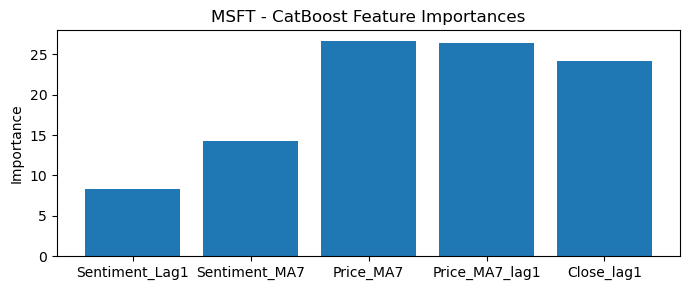

```
=== NVDA Feature Importances ===
```

[8 more figures not shown]

```python
# Feature Importance Visualization for Tree-Based Models (Week 7)
import matplotlib.pyplot as plt
import numpy as np

tree_models = ['RandomForest', 'XGBoost', 'LightGBM', 'CatBoost']
feature_names = ['Sentiment_Lag1', 'Sentiment_MA7', 'Price_MA7', 'Price_MA7_lag1', 'Close_lag1']

for symbol, df in features_data.items():
    print(f"\n=== {symbol} Feature Importances ===")
    X = df[feature_names]
    y = df['Return']
    X_train, X_test, y_train, y_test = train_test_split(X, y, test_size=0.2, shuffle=False)
    models = {
        'RandomForest': RandomForestRegressor(random_state=42),
        'XGBoost': xgb.XGBRegressor(random_state=42, verbosity=0),
        'LightGBM': lgb.LGBMRegressor(random_state=42),
        'CatBoost': cb.CatBoostRegressor(verbose=0, random_state=42)
    }
    for name, model in models.items():
        model.fit(X_train, y_train)
        if hasattr(model, 'feature_importances_'):
            importances = model.feature_importances_
        else:
            importances = model.get_booster().get_score(importance_type='weight')
            importances = np.array([importances.get(f'f{i}', 0) for i in range(len(feature_names))])
        plt.figure(figsize=(7, 3))
        plt.bar(feature_names, importances)
        plt.title(f'{symbol} - {name} Feature Importances')
        plt.ylabel('Importance')
        plt.tight_layout()
        plt.show()
```

```python
# Record non-hyper-tuned results for all companies, models, and feature sets
from collections import defaultdict
non_tuned_results = []
from sklearn.linear_model import LinearRegression, Ridge, Lasso
from sklearn.ensemble import RandomForestRegressor
from xgboost import XGBRegressor
from lightgbm import LGBMRegressor
from catboost import CatBoostRegressor
from sklearn.svm import SVR
from sklearn.neighbors import KNeighborsRegressor

non_tuned_models = {
    'Linear': LinearRegression(),
    'Ridge': Ridge(),
    'Lasso': Lasso(),
    'RandomForest': RandomForestRegressor(random_state=42),
    'XGBoost': XGBRegressor(random_state=42, verbosity=0),
    'LightGBM': LGBMRegressor(random_state=42),
    'CatBoost': CatBoostRegressor(verbose=0, random_state=42),
    'SVR': SVR(),
    'KNN': KNeighborsRegressor()
}

for symbol, df in features_data.items():
    for feature_set, features in [
        ('Price-only', ['Price_MA7', 'Price_MA7_lag1', 'Close_lag1']),
        ('Price+Sentiment', ['Sentiment_Lag1', 'Sentiment_MA7', 'Price_MA7', 'Price_MA7_lag1', 'Close_lag1'])
    ]:
        X = df[features]
        y = df['Return']
        X_train, X_test, y_train, y_test = train_test_split(X, y, test_size=0.2, shuffle=False)
        for name, model in non_tuned_models.items():
            try:
                model.fit(X_train, y_train)
                preds = model.predict(X_test)
                r2 = r2_score(y_test, preds)
                mse = mean_squared_error(y_test, preds)
                non_tuned_results.append({
                    'Symbol': symbol,
                    'Feature Set': feature_set,
                    'Model': name,
                    'Test R2': r2,
                    'Test MSE': mse
                })
            except Exception as e:
                non_tuned_results.append({
                    'Symbol': symbol,
                    'Feature Set': feature_set,
                    'Model': name,
                    'Test R2': None,
                    'Test MSE': None,
                    'Error': str(e)
                })
import pandas as pd
non_tuned_results_df = pd.DataFrame(non_tuned_results)
display(non_tuned_results_df)
```

[output not shown]

[output cut: 1940 more lines]

[output not shown]

|  | Symbol | Feature Set | Model | Test R2 | Test MSE |
| --- | --- | --- | --- | --- | --- |
| 0 | TSLA | Price-only | Linear | 0.435078 | 0.001737 |
| 1 | TSLA | Price-only | Ridge | 0.435068 | 0.001737 |
| 2 | TSLA | Price-only | Lasso | -0.001727 | 0.003080 |
| 3 | TSLA | Price-only | RandomForest | -0.394311 | 0.004287 |
| 4 | TSLA | Price-only | XGBoost | -0.922313 | 0.005910 |
| ... | ... | ... | ... | ... | ... |
| 85 | GOOG | Price+Sentiment | XGBoost | -0.104498 | 0.000678 |
| 86 | GOOG | Price+Sentiment | LightGBM | 0.070696 | 0.000570 |
| 87 | GOOG | Price+Sentiment | CatBoost | 0.055032 | 0.000580 |
| 88 | GOOG | Price+Sentiment | SVR | -0.362469 | 0.000836 |
| 89 | GOOG | Price+Sentiment | KNN | -0.033695 | 0.000634 |

90 rows × 5 columns

```python
# Display side-by-side comparison of non-hyper-tuned and hyper-tuned results

if 'results_df' in globals() and 'non_tuned_results_df' in globals():
    def display_comparison(symbol, feature_set):
        print(f"\n=== {symbol} | {feature_set} ===")
        nt = non_tuned_results_df[(non_tuned_results_df['Symbol'] == symbol) & (non_tuned_results_df['Feature Set'] == feature_set)]
        ht = results_df[(results_df['Symbol'] == symbol) & (results_df['Feature Set'] == feature_set)]
        merged = pd.merge(nt, ht, on=['Symbol', 'Feature Set', 'Model'], how='outer', suffixes=('_NonTuned', '_Tuned'))
        display(merged['Model', 'Test R2_NonTuned', 'Test MSE_NonTuned', 'Test R2_Tuned', 'Test MSE_Tuned'])

    symbols = non_tuned_results_df['Symbol'].unique()
    feature_sets = non_tuned_results_df['Feature Set'].unique()

    for symbol in symbols:
        for feature_set in feature_sets:
            display_comparison(symbol, feature_set)
else:
    print("Please ensure both 'results_df' and 'non_tuned_results_df' are defined before running this cell.")
```

```
Please ensure both 'results_df' and 'non_tuned_results_df' are defined before running this cell.
```

### Summary & Interpretation

**Recommendation:**

- Use the best-performing, hyperparameter-tuned model for each company and feature set.
- Consider the trade-off between model complexity and performance gains when choosing between linear and advanced models.
- If sentiment features consistently improve results, prioritize their inclusion in future pipelines.

```python
# Week 8: Summary and Hyperparameter Tuning

#In the final week, we summarize all findings and perform hyperparameter tuning for all major models (Random Forest, XGBoost, LightGBM, CatBoost, SVM, KNN, and linear models) on both price-only and price+sentiment features. This ensures a fair comparison and helps determine if sentiment features ever outperform price-only features.
```

```python
# Week 8: Record and Compare Non-Tuned and Tuned Results for All Companies
from sklearn.model_selection import train_test_split, GridSearchCV
from sklearn.linear_model import LinearRegression, Ridge, Lasso
from sklearn.ensemble import RandomForestRegressor
from xgboost import XGBRegressor
from lightgbm import LGBMRegressor
from catboost import CatBoostRegressor
from sklearn.svm import SVR
from sklearn.neighbors import KNeighborsRegressor
from sklearn.metrics import mean_squared_error, r2_score
import pandas as pd

# Define models and param grids
non_tuned_models = {
    'Linear': LinearRegression(),
    'Ridge': Ridge(),
    'Lasso': Lasso(),
    'RandomForest': RandomForestRegressor(random_state=42),
    'XGBoost': XGBRegressor(random_state=42, verbosity=0),
    'LightGBM': LGBMRegressor(random_state=42),
    'CatBoost': CatBoostRegressor(verbose=0, random_state=42),
    'SVR': SVR(),
    'KNN': KNeighborsRegressor()
}
param_grids = {
    'RandomForest': {
        'n_estimators': [100, 200],
        'max_depth': [3, 5, 10, None],
        'min_samples_split': [2, 5, 10]
    },
    'XGBoost': {
        'n_estimators': [100, 200],
        'max_depth': [3, 5, 10],
        'learning_rate': [0.01, 0.1, 0.2]
    },
    'LightGBM': {
        'n_estimators': [100, 200],
        'max_depth': [3, 5, 10, -1],
        'learning_rate': [0.01, 0.1, 0.2]
    },
    'CatBoost': {
        'iterations': [100, 200],
        'depth': [3, 5, 10],
        'learning_rate': [0.01, 0.1, 0.2]
    },
    'SVR': {
        'C': [0.1, 1, 10],
        'kernel': ['rbf', 'linear'],
        'gamma': ['scale', 'auto']
    },
    'KNN': {
        'n_neighbors': [3, 5, 10],
        'weights': ['uniform', 'distance']
    },
    'Ridge': {
        'alpha': [0.01, 0.1, 1, 10]
    },
    'Lasso': {
        'alpha': [0.01, 0.1, 1, 10]
    }
}
tuned_models = {
    'RandomForest': RandomForestRegressor(random_state=42),
    'XGBoost': XGBRegressor(random_state=42, verbosity=0),
    'LightGBM': LGBMRegressor(random_state=42),
    'CatBoost': CatBoostRegressor(verbose=0, random_state=42),
    'SVR': SVR(),
    'KNN': KNeighborsRegressor(),
    'Ridge': Ridge(),
    'Lasso': Lasso()
}

non_tuned_results = []
tuned_results = []
companies = list(features_data.keys())

for symbol, df in features_data.items():
    for feature_set, features in [
        ('Price-only', ['Price_MA7', 'Price_MA7_lag1', 'Close_lag1']),
        ('Price+Sentiment', ['Sentiment_Lag1', 'Sentiment_MA7', 'Price_MA7', 'Price_MA7_lag1', 'Close_lag1'])
    ]:
        X = df[features]
        y = df['Return']
        X_train, X_test, y_train, y_test = train_test_split(X, y, test_size=0.2, shuffle=False)
        # Non-tuned
        for name, model in non_tuned_models.items():
            try:
                model.fit(X_train, y_train)
                preds = model.predict(X_test)
                r2 = r2_score(y_test, preds)
                mse = mean_squared_error(y_test, preds)
                non_tuned_results.append({
                    'Symbol': symbol,
                    'Feature Set': feature_set,
                    'Model': name,
                    'Test R2': r2,
                    'Test MSE': mse
                })
            except Exception as e:
                non_tuned_results.append({
                    'Symbol': symbol,
                    'Feature Set': feature_set,
                    'Model': name,
                    'Test R2': None,
                    'Test MSE': None,
                    'Error': str(e)
                })
        # Tuned
        for name, model in tuned_models.items():
            try:
                grid = GridSearchCV(model, param_grids[name], cv=3, scoring='r2', n_jobs=-1)
                grid.fit(X_train, y_train)
                best_model = grid.best_estimator_
                preds = best_model.predict(X_test)
                r2 = r2_score(y_test, preds)
                mse = mean_squared_error(y_test, preds)
                tuned_results.append({
                    'Symbol': symbol,
                    'Feature Set': feature_set,
                    'Model': name,
                    'Best Params': grid.best_params_,
                    'Test R2': r2,
                    'Test MSE': mse
                })
            except Exception as e:
                tuned_results.append({
                    'Symbol': symbol,
                    'Feature Set': feature_set,
                    'Model': name,
                    'Best Params': None,
                    'Test R2': None,
                    'Test MSE': None,
                    'Error': str(e)
                })

non_tuned_results_df = pd.DataFrame(non_tuned_results)
tuned_results_df = pd.DataFrame(tuned_results)
display(non_tuned_results_df)
display(tuned_results_df)

# Create summary table: Non-Tuned vs Tuned R2 for each company (best model per company/feature set)
summary_rows = []
for symbol in companies:
    for feature_set in ['Price-only', 'Price+Sentiment']:
        # Best non-tuned
        nt = non_tuned_results_df[(non_tuned_results_df['Symbol'] == symbol) & (non_tuned_results_df['Feature Set'] == feature_set)]
        nt_best = nt.loc[nt['Test R2'].idxmax()] if not nt.empty else None
        # Best tuned
        tt = tuned_results_df[(tuned_results_df['Symbol'] == symbol) & (tuned_results_df['Feature Set'] == feature_set)]
        tt_best = tt.loc[tt['Test R2'].idxmax()] if not tt.empty else None
        summary_rows.append({
            'Company': symbol,
            'Feature Set': feature_set,
            'Non-Tuned Best Model': nt_best['Model'] if nt_best is not None else None,
            'Non-Tuned R2': nt_best['Test R2'] if nt_best is not None else None,
            'Tuned Best Model': tt_best['Model'] if tt_best is not None else None,
            'Tuned R2': tt_best['Test R2'] if tt_best is not None else None
        })
summary_df = pd.DataFrame(summary_rows)
# Show summary table with two columns: Non-Tuned R2, Tuned R2
summary_table = summary_df[['Company', 'Feature Set', 'Non-Tuned R2', 'Tuned R2']]
display(summary_table)
non_tuned_results_df.to_csv("non_tuned_results.csv", index=False)
tuned_results_df.to_csv("tuned_results.csv", index=False)
summary_df.to_csv("summary_table.csv", index=False)
```

[output not shown]

[output cut: 260 more lines]

[output not shown]

[output not shown]

[output cut: 260 more lines]

[output not shown]

[output not shown]

[output cut: 3600 more lines]

[output not shown]

|  | Symbol | Feature Set | Model | Test R2 | Test MSE |
| --- | --- | --- | --- | --- | --- |
| 0 | TSLA | Price-only | Linear | 0.435078 | 0.001737 |
| 1 | TSLA | Price-only | Ridge | 0.435068 | 0.001737 |
| 2 | TSLA | Price-only | Lasso | -0.001727 | 0.003080 |
| 3 | TSLA | Price-only | RandomForest | -0.394311 | 0.004287 |
| 4 | TSLA | Price-only | XGBoost | -0.922313 | 0.005910 |
| ... | ... | ... | ... | ... | ... |
| 85 | GOOG | Price+Sentiment | XGBoost | -0.104498 | 0.000678 |
| 86 | GOOG | Price+Sentiment | LightGBM | 0.070696 | 0.000570 |
| 87 | GOOG | Price+Sentiment | CatBoost | 0.055032 | 0.000580 |
| 88 | GOOG | Price+Sentiment | SVR | -0.362469 | 0.000836 |
| 89 | GOOG | Price+Sentiment | KNN | -0.033695 | 0.000634 |

90 rows × 5 columns

|  | Symbol | Feature Set | Model | Best Params | Test R2 | Test MSE |
| --- | --- | --- | --- | --- | --- | --- |
| 0 | TSLA | Price-only | RandomForest | {'max_depth': 3, 'min_samples_split': 2, 'n_es... | -0.043919 | 0.003210 |
| 1 | TSLA | Price-only | XGBoost | {'learning_rate': 0.01, 'max_depth': 3, 'n_est... | -0.048888 | 0.003225 |
| 2 | TSLA | Price-only | LightGBM | {'learning_rate': 0.01, 'max_depth': 3, 'n_est... | -0.044550 | 0.003212 |
| 3 | TSLA | Price-only | CatBoost | {'depth': 3, 'iterations': 100, 'learning_rate... | -0.011537 | 0.003110 |
| 4 | TSLA | Price-only | SVR | {'C': 0.1, 'gamma': 'scale', 'kernel': 'rbf'} | -0.174440 | 0.003611 |
| ... | ... | ... | ... | ... | ... | ... |
| 75 | GOOG | Price+Sentiment | CatBoost | {'depth': 3, 'iterations': 100, 'learning_rate... | -0.013856 | 0.000622 |
| 76 | GOOG | Price+Sentiment | SVR | {'C': 0.1, 'gamma': 'scale', 'kernel': 'rbf'} | -0.362469 | 0.000836 |
| 77 | GOOG | Price+Sentiment | KNN | {'n_neighbors': 10, 'weights': 'uniform'} | -0.038240 | 0.000637 |
| 78 | GOOG | Price+Sentiment | Ridge | {'alpha': 1} | 0.413234 | 0.000360 |
| 79 | GOOG | Price+Sentiment | Lasso | {'alpha': 0.01} | -0.001041 | 0.000614 |

80 rows × 6 columns

|  | Company | Feature Set | Non-Tuned R2 | Tuned R2 |
| --- | --- | --- | --- | --- |
| 0 | TSLA | Price-only | 0.435078 | 0.434921 |
| 1 | TSLA | Price+Sentiment | 0.452738 | 0.450885 |
| 2 | AAPL | Price-only | 0.323902 | 0.323195 |
| 3 | AAPL | Price+Sentiment | 0.355983 | 0.355201 |
| 4 | MSFT | Price-only | 0.437497 | 0.439787 |
| 5 | MSFT | Price+Sentiment | 0.429493 | 0.433106 |
| 6 | NVDA | Price-only | 0.469603 | 0.469528 |
| 7 | NVDA | Price+Sentiment | 0.472126 | 0.468703 |
| 8 | GOOG | Price-only | 0.406640 | 0.406640 |
| 9 | GOOG | Price+Sentiment | 0.413234 | 0.413234 |